# ds202_lab3

Gabe Love

10/4/2021

# Question 1

```r
df <- readxl::read_xls("GSS.xls")
df$`Highest year of school completed` <- as.integer(df$`Highest year of school completed`)
```

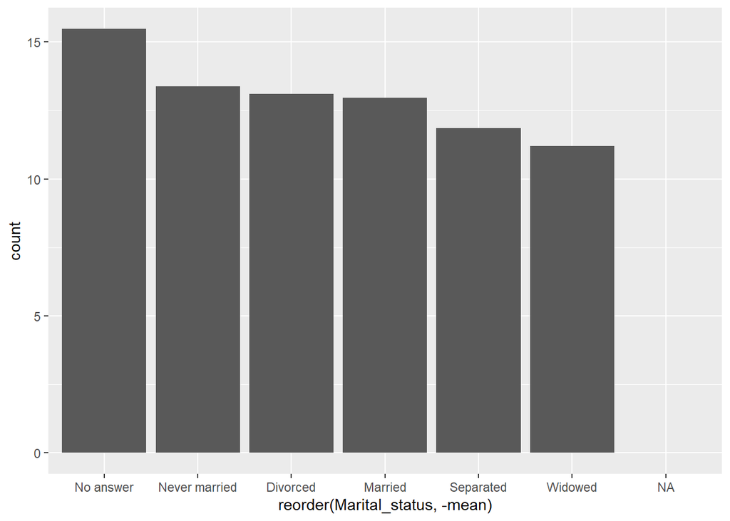

```r
names(df) <- gsub(" ", "_", names(df))

avgEdu <- df %>% group_by(Marital_status)
avgEdu <- summarise(avgEdu, mean = mean(Highest_year_of_school_completed, na.rm = TRUE))
avgEdu <- arrange(avgEdu, mean)

ggplot(avgEdu, aes( x= reorder(Marital_status, -mean), weight = mean)) + geom_bar()
```

# Question 2

```r
df <- readxl::read_xls("GSS.xls")
df$`Highest year of school completed` <- as.integer(df$`Highest year of school completed`)
names(df) <- gsub(" ", "_", names(df))

betterEdu <- filter(df, (Marital_status == 'Widowed' & Highest_year_of_school_completed > 11.2 ) |
                      (Marital_status == 'Seperated' & Highest_year_of_school_completed > 11.9 ) |
                      (Marital_status == 'Married' & Highest_year_of_school_completed > 13 ) |
                      (Marital_status == 'Divorced' & Highest_year_of_school_completed > 13.1 ) |
                      (Marital_status == 'Never Married' & Highest_year_of_school_completed > 13.4 ) |
                      (Marital_status == 'No answer' & Highest_year_of_school_completed > 15.5))

str(betterEdu)
```

```
## tibble [20,438 x 9] (S3: tbl_df/tbl/data.frame)
##  $ Gss_year_for_this_respondent     : num [1:20438] 1972 1972 1972 1972 1972 ...
##  $ Respondent_id_number             : num [1:20438] 4 16 17 19 25 32 36 42 52 57 ...
##  $ Marital_status                   : chr [1:20438] "Married" "Married" "Married" "Married" ...
##  $ Highest_year_of_school_completed : int [1:20438] 17 14 14 17 16 14 14 14 14 14 ...
##  $ Respondents_sex                  : chr [1:20438] "Female" "Male" "Male" "Female" ...
##  $ Mothers_employment_since_marriage: chr [1:20438] "Not applicable" "Not applicable" "Not applicable" "Not applicable" ...
##  $ Political_party_affiliation      : chr [1:20438] "Not str democrat" "Strong democrat" "Ind,near rep" "Ind,near dem" ...
##  $ General_happiness                : chr [1:20438] "Not too happy" "Not too happy" "Very happy" "Very happy" ...
##  $ Ballot_used_for_interview        : chr [1:20438] "Not applicable" "Not applicable" "Not applicable" "Not applicable" ...
```

# Question 3

```r
df <- readxl::read_xls("GSS.xls")
df$`Highest year of school completed` <- as.integer(df$`Highest year of school completed`)
names(df) <- gsub(" ", "_", names(df))

df <- group_by(df, Marital_status) %>% summarise(totals = n(), General_happiness = General_happiness) %>%
  group_by(General_happiness, .add = TRUE) %>% summarise(happinessScore = n(), totals = totals, score = 100*happinessScore/totals) %>% unique() %>%
  filter(General_happiness == "Pretty happy" | General_happiness == "Very happy") %>% summarise(score = score) %>%
  summarise(score = sum(score))
df
```

```
## # A tibble: 6 x 2
##   Marital_status score
##   <chr>          <dbl>
## 1 Divorced        73.8
## 2 Married         86.0
## 3 Never married   77.2
## 4 No answer       59.3
## 5 Separated       66.3
## 6 Widowed         75.4
```

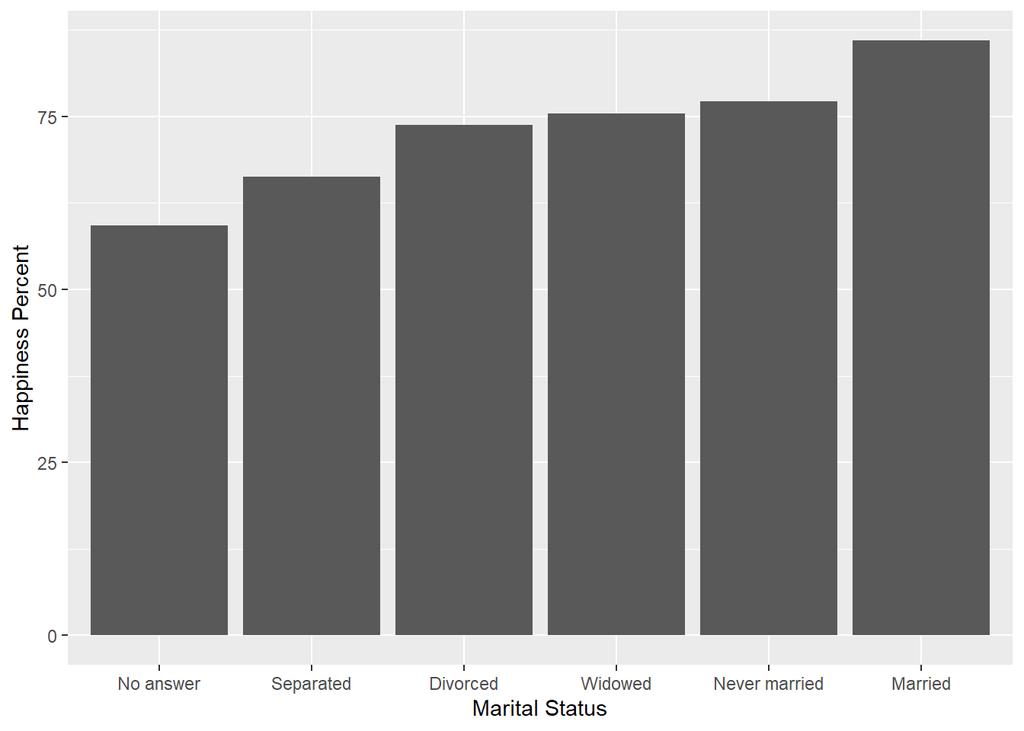

```r
ggplot(df, aes(x=reorder(Marital_status, score), weight = score)) + geom_bar() + xlab("Marital Status") + ylab("Happiness Percent")
```

To answer this question, I grouped the data by marital status as well as happiness. To find the happiness score that I am using to order marital status, I found the total number of repsonses for each marital status and then divided the number of responses for each happiness level by that number. I found that those who are married tend to be the happiest.

# Question 4

```r
df <- readxl::read_xls("GSS.xls")
df$`Highest year of school completed` <- as.integer(df$`Highest year of school completed`)
names(df) <- gsub(" ", "_", names(df))

df <- group_by(df, Political_party_affiliation) %>% group_by(Marital_status, .add = TRUE) %>%
  summarise(totals = n(), General_happiness = General_happiness) %>%
  group_by(General_happiness, .add = TRUE) %>% summarise(happinessScore = n(), totals = totals, score = 100*happinessScore/totals) %>%
  summarise(score = mean(score)) %>% unique() %>%
  filter(General_happiness == "Pretty happy" | General_happiness == "Very happy") %>% summarise(score = score) %>%
  summarise(score = sum(score))
df
```

```
## # A tibble: 56 x 3
## # Groups:   Political_party_affiliation [10]
##    Political_party_affiliation Marital_status score
##    <chr>                       <chr>          <dbl>
##  1 Don't know                  Married        100
##  2 Don't know                  Never married   50
##  3 Don't know                  Widowed         50
##  4 Ind,near dem                Divorced        74.4
##  5 Ind,near dem                Married         86.0
##  6 Ind,near dem                Never married   76.7
##  7 Ind,near dem                No answer       50
##  8 Ind,near dem                Separated       64.5
##  9 Ind,near dem                Widowed         74.1
## 10 Ind,near rep                Divorced        77.9
## # ... with 46 more rows
```

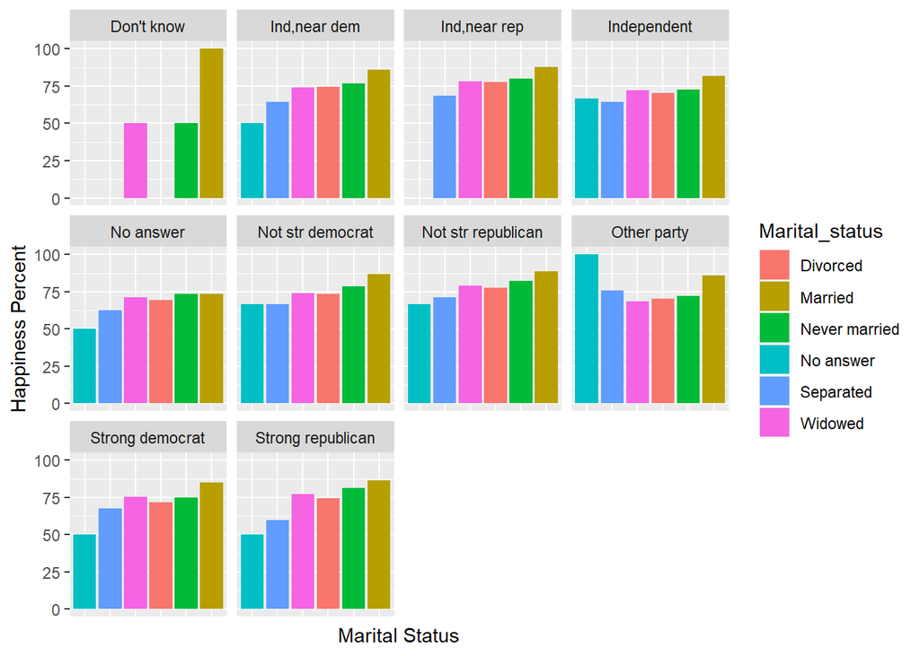

```r
ggplot(df, aes(x=reorder(Marital_status, score), weight = score, fill = Marital_status)) + geom_bar() + xlab("Marital Status") +
  ylab("Happiness Percent") + facet_wrap(~Political_party_affiliation) + theme(axis.text.x = element_blank(), axis.ticks.x=element_blank())
```

Very similar to question three, I grouped my data by happiness and marital status, but this time I also grouped by political affiliation. I found that political affiliation did not change the results much, as those who are married still are the happiness in most cases.